# Sklep X

Michał Lewsza

2020-12-29

## Analiza sprzedaży i wydatków reklamowych

### Korelacja

Badaniu korelacji zostaną poddane parametry ilościowe opisujące natężenie kampanii*(e.g. budżet, wyświetlenia, zasięgi, klikniecia)* i wyniki sprzedaży *(przychód, liczba dokonanych zamówień, liczba sprzedanych produktów)*. Dodatkowo, parametry natężenia kampanii zostaną opóźnione w celu zbadania opóźnionego efektu na sprzedaż:

```
## # A tibble: 14 x 4
##    variable         liczba_zam liczba_prod przychod
##    <chr>                 <dbl>       <dbl>    <dbl>
##  1 zasieg                0.672       0.666    0.671
##  2 wyswietlenia          0.673       0.667    0.671
##  3 budzet                0.757       0.749    0.749
##  4 kliki                 0.800       0.790    0.796
##  5 zakupy_fb             0.846       0.845    0.843
##  6 komenty_post          0.720       0.700    0.705
##  7 reakcje_post          0.795       0.789    0.797
##  8 przychod              0.985       0.999    1
##  9 liczba_prod           0.985       1        0.999
## 10 liczba_zam            1           0.985    0.985
## 11 nowe_zakazenia       -0.194      -0.176   -0.182
## 12 przyrost_zakazen      0.134       0.131    0.141
## 13 zakazenia_lag1       -0.255      -0.235   -0.245
## 14 temp                  0.248       0.229    0.240
```

Wskaźniki korelacji wykazują silną, pozytywną(>0,5) korelację pomiędzy intensywnością kampanii a wynikami sprzedaży. Można stwierdzić, że istnieje silna bezpośrednia zależność między wydatkami reklamowymi a przychodem ze sprzedaży (korelacja: 0.749).

Równie silna zależność w kontekście przychodów występuje w przypadku takich parametrów jak: ‘kliknięcia’, ‘komentarze postow’, ‘reakcje na posty’.

Poniższy wykres obrazuje korelację wydatków na reklamę z przychodem w zależności od rzędu opóźnienia *(e.g. korelacja dla rzędu = 2 mówi jaki związek mają przedwczorajsze wydatki z dzisiejszym przychodem)* Z każdym kolejnym opóźnieniem korelacja maleje, co znaczy, że **wydatki na reklamę mają największe przełożenie na przychód tego samego dnia.**

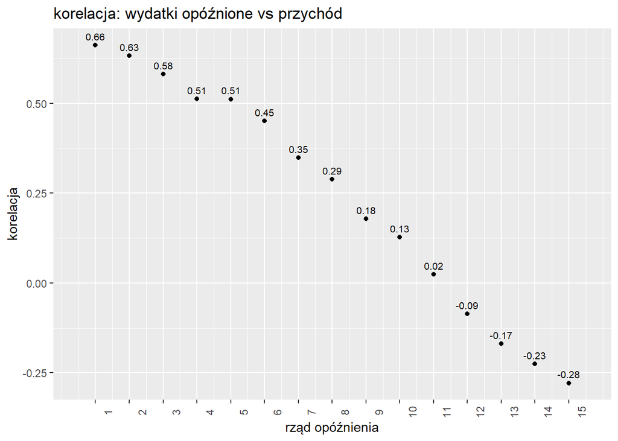

Wydatki z kolejnymi opóźnieniami cechują się również wysokimi wskaźnikami korelacji. Jednak może to dawać złudny obraz, ponieważ sam szereg czasowy wydatków na reklamę cechuje się silną autokorelacją o czym świadczy poniższy wykres:

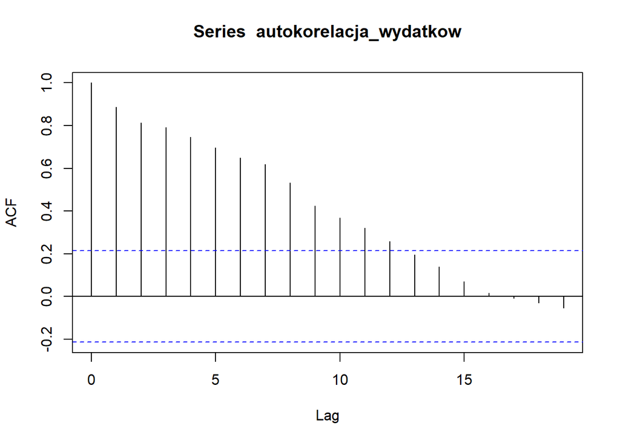

**Podsumowując:** najrozsądniej jest przyjąć hipotezę, mówiącą, że wydatki na reklamę mają silny wpływ na przychód **tego samego dnia.**

### Kolor czapek

W tej zakładce odpowiemy graficznie na proste pytania związane ze sprzedażą czapek ze względu na kolor:

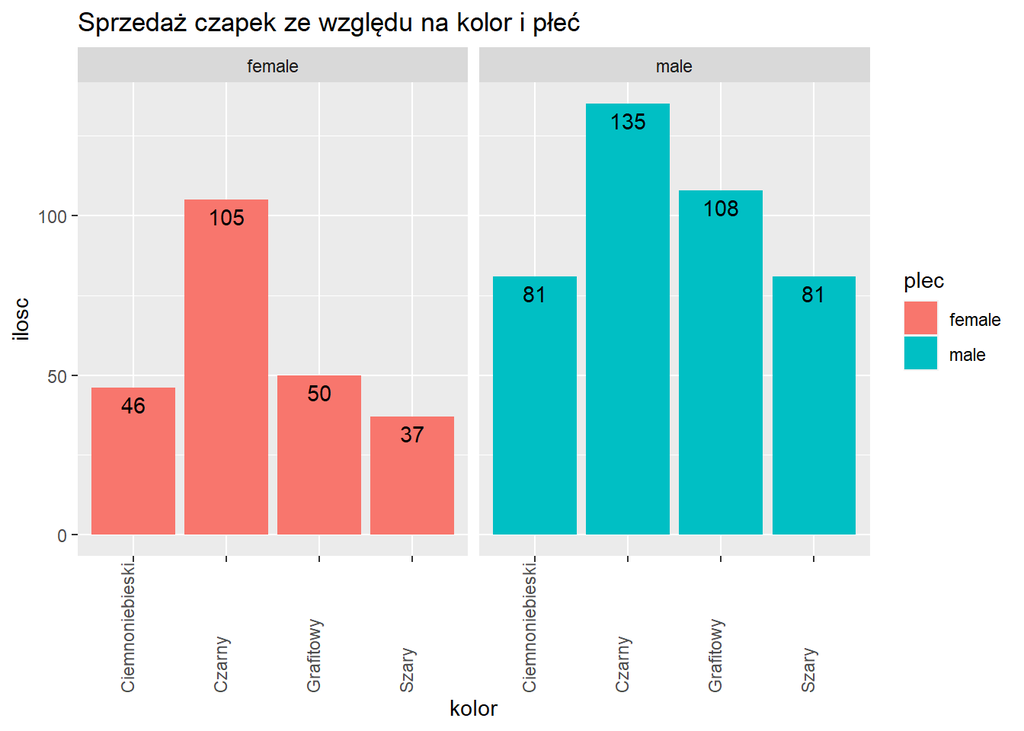

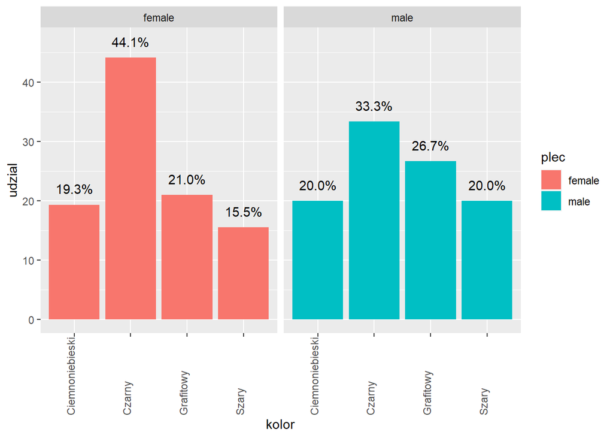

### Efekt dnia tygodnia

Czy dzień tygodnia ma wpływ na sprzedaż czapek Kiowi?

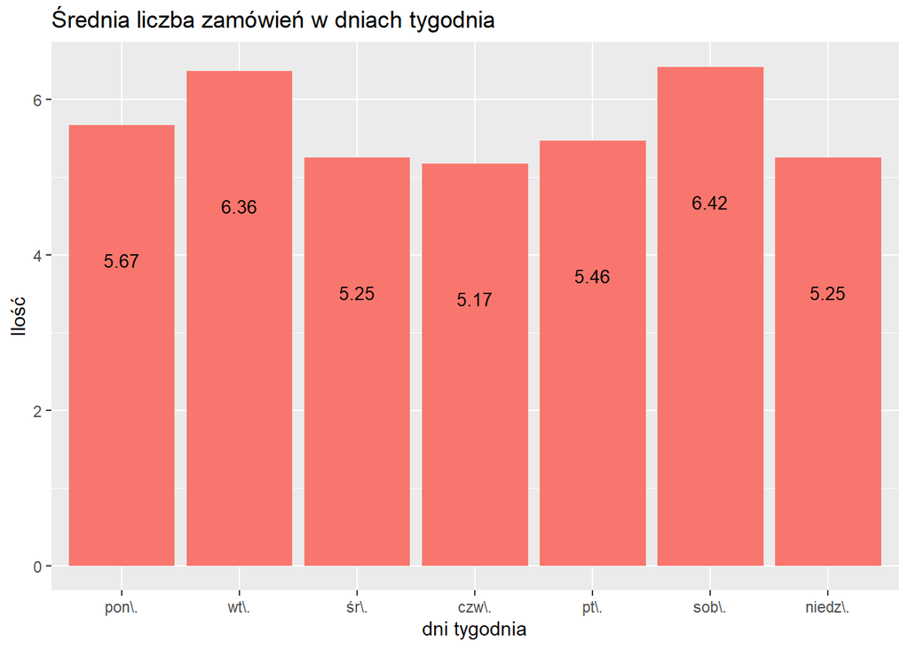

Wtorki i soboty to dni kiedy klienci najchętniej składają zamówienia. Nie można wyróżnić jednego dnia z istotnie najniższą liczbą zamówień. Bardziej szczegółowych danych dostarczy nam wizualizacja na wykresie pudełkowym.

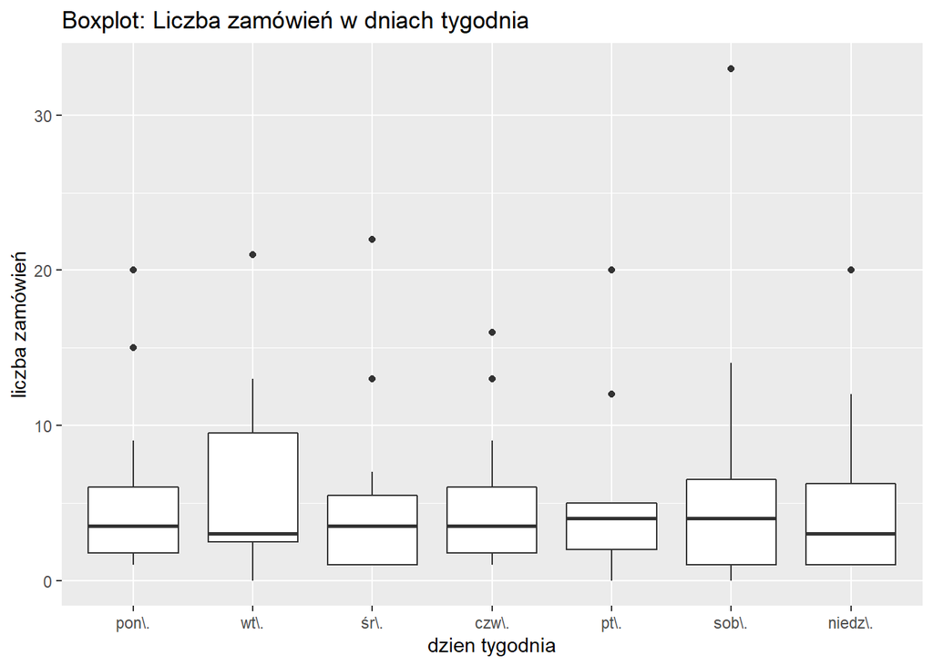

Liczba zamówień na wykresie pudełkowym obrazuje, że wszystkie dni mają medianę na podobynm poziomie (3-4 zamówienia). Jednak wtorek, sobota i niedziela są bardziej podatne na odchylenia w kierunku większej ilości zamówień (długie wąsy górne)

Spróbujemy wykluczyć hipotezę, że na te odchylenia miały wpływ jedynie dni tygodnia, bez udziału wpływu budżetu reklamowego.

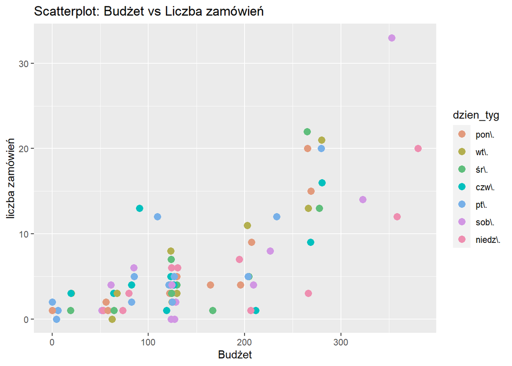

Widzimy, że obserwacje odchylone i odstające w sobotę i niedzielę wiązały się z największymi nakładami reklamowymi (4 maksymalnie wychylone punkty względem osi poziomej) Dlatego hipoteza, że to nakłady reklamowe decydowały o odchyleniach w wyżej wspomnianych dniach tygodnia wydaje się bliższa rzeczywistości, niż hipoteza o efekcie tygodnia, którą najprawdopodbiej odrzucimy.

Aby zweryfikować hipotezy o wpływie dni tygodnia przeprowadzimy dwuczynnikową analizę wariancji z interakcją. Zbadaniu wpływu na liczbę zamówień zostaną poddane trzy czynniki: dzień tygodnia, budżet oraz interakcja dnia tygodnia z budżetem (być może tylko któryś dzień tygodnia w połączeniu z budżetem daje istotnie różne wyniki)

```
##                  Df Sum Sq Mean Sq F value   Pr(>F)
## dzien_tyg         6   19.8     3.3   0.195    0.977
## budzet            1 1917.1  1917.1 113.244 2.83e-16 ***
## dzien_tyg:budzet  6  121.5    20.2   1.196    0.319
## Residuals        70 1185.0    16.9
## ---
## Signif. codes:  0 '***' 0.001 '**' 0.01 '*' 0.05 '.' 0.1 ' ' 1
```

Wyniki analizy wariancji mówią nam, że **jedynie czynnik budżetu istotnie wpływa na liczbę zamówień.** Ostatecznie odrzucamy hipotezę mówiącą o efekcie dnia tygodnia.

Zarówno w tym teście jak i poprzednim rozdziale o korelacji, zauważyliśmy, że budżet reklamowy ma istotny, i silny wpływ na zamówienia. Mimo to, musimy założyć, że ten wpływ ma swój ograniczony zakres. Dlatego zakładamy, że istnieje punkt przegięcia - punkt w którym dodatkowe nakłady nie dają proporcjonalnych korzyści. Poniższe dwa wykresy mogą stanowić ku temu przesłankę.

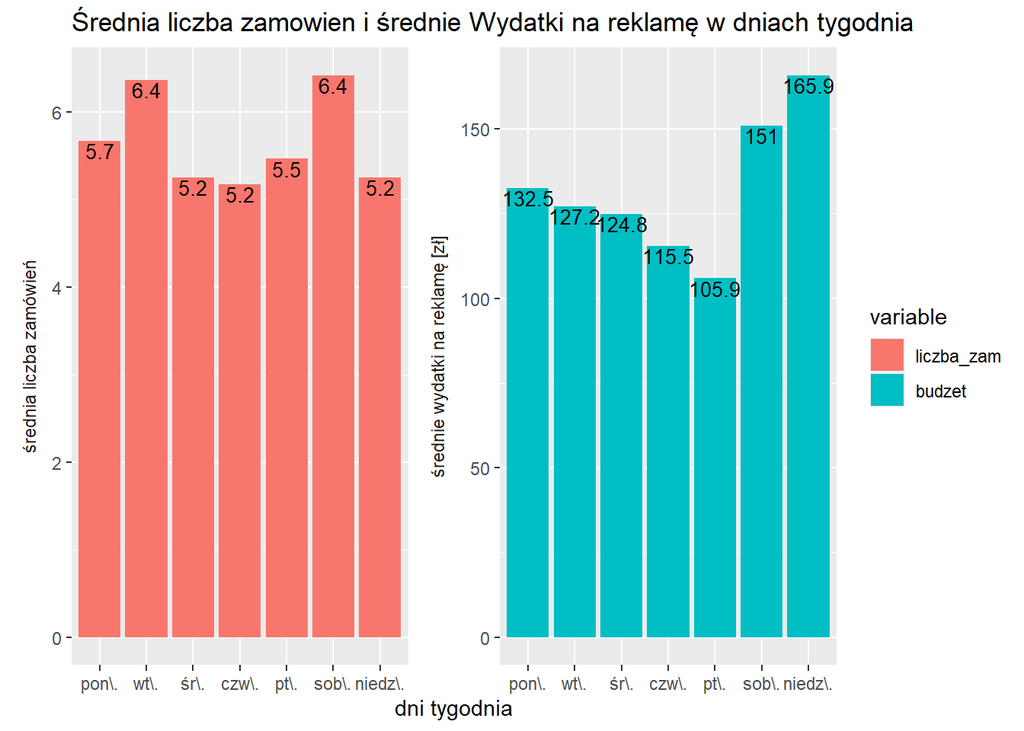

Widzimy, że zwiększone wydatki w niedziele nie znalazły odzwierciedlenia w liczbie zamówień.

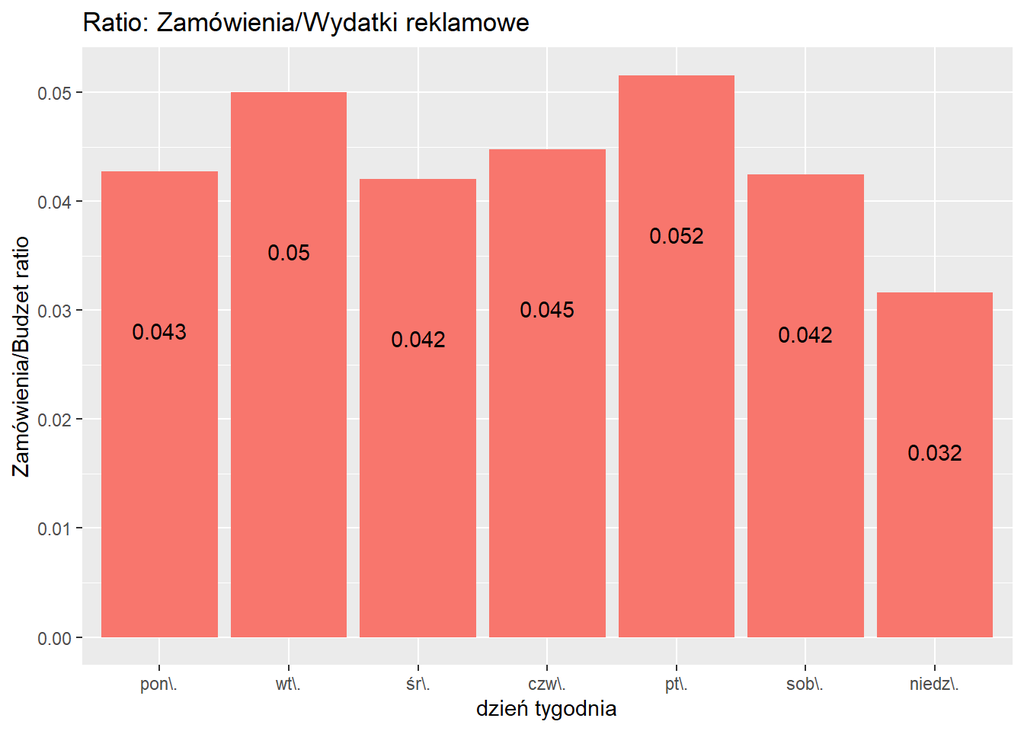

W efekcie wskaźnik efektywności (iloraz: zamówienia/budżet) jest najniższy właśnie dla niedzieli. Zagadnienie punktu przegięcia będzie rozwijane w kolejnych zakładkach.

### Pogoda i zakażenia

Do analizy włączmy inny czynnik, który być może, okaże się również istotny: kolor punktów będzie reprezentował liczbę odnotowanych pozytywnych przypadków COVID w Polsce.

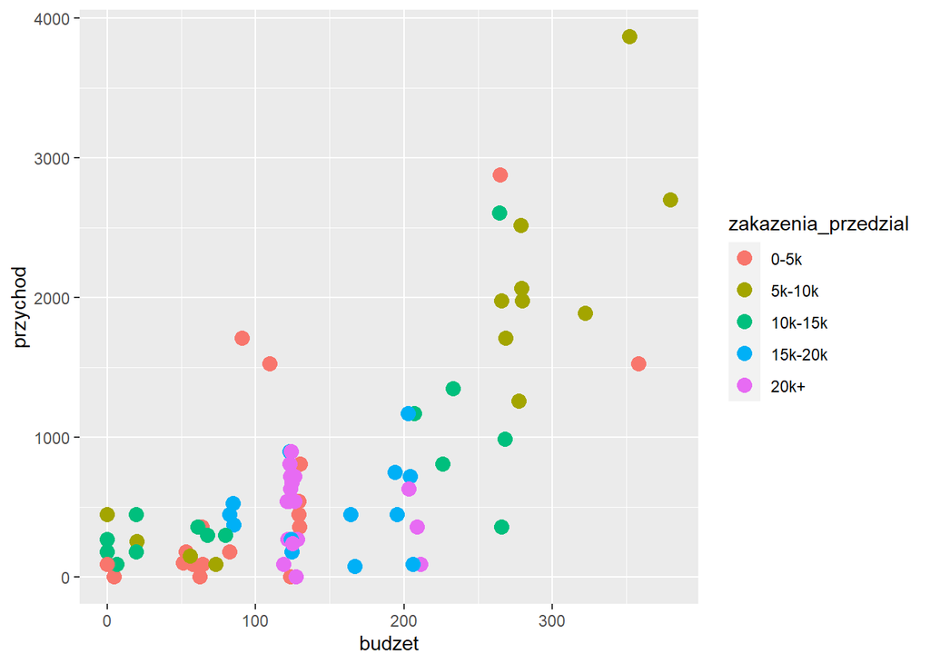

Po kolorze punktów, widzimy, że wysoka liczba zachorowań wcale nie znajdowała odbicia w zwiększonych przychodach. Najbardziej przychodowe dni przypadały wtedy, gdy liczba zachorowań oscylowała w przedziale 5-10 tys nowych zakażeń. Mogło to być związane z wpływem psychologicznym i niepokojem, kiedy liczba zakażeń zaczęła gwałtownie rosnąć, a może to efekt sezonu, kiedy czapki z daszkiem najlepiej nadają się do noszenia. Spróbujmy stworzyć ten sam wykres, ale tym razem kolor będzie reprezentował miesiąc.

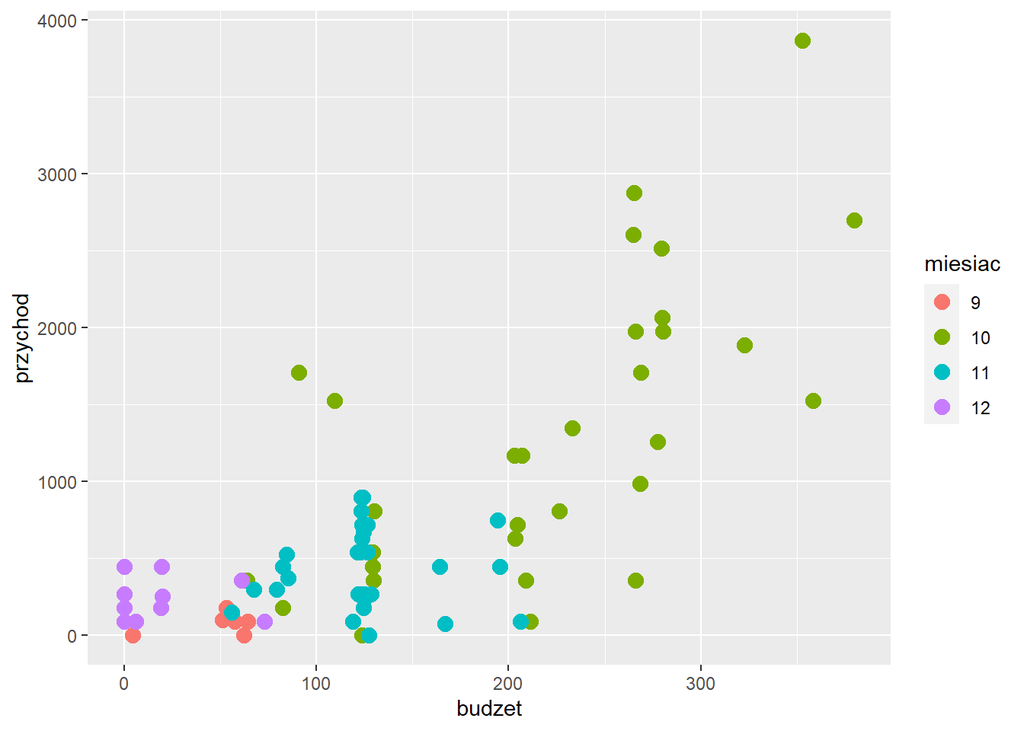

Widzimy, że największe przychody są ściśle przywiązane do października.

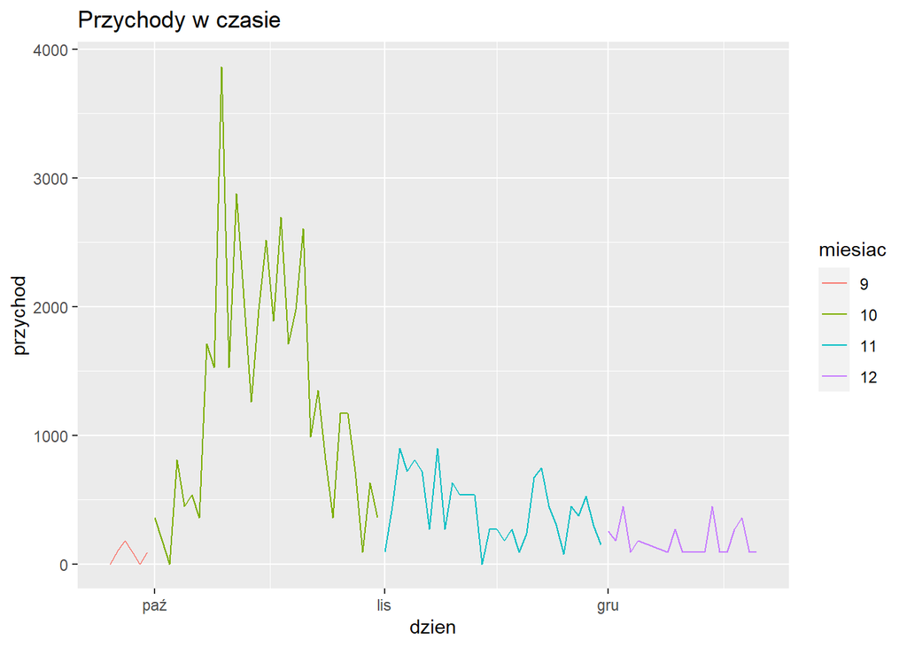

Powyższy wykres potwierdza, że sklep miał największy ruch w październiku

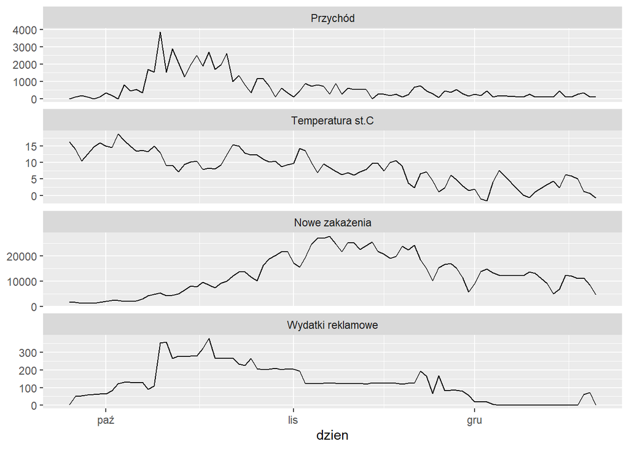

Na powyższych wykresach widzimy, że przychód zaczyna spadać w drugiej połowie października, a w tym momencie:

- temperatura zaczyna łagodnie spadać
- nowe zakażenia osiągają maxima, chwilowo spadają, by potem ponownie zaliczyć gwałtowny przyrost
- utrzymywane są nakłady reklamowe

Ten sam wykres z “zoomem” na październik:

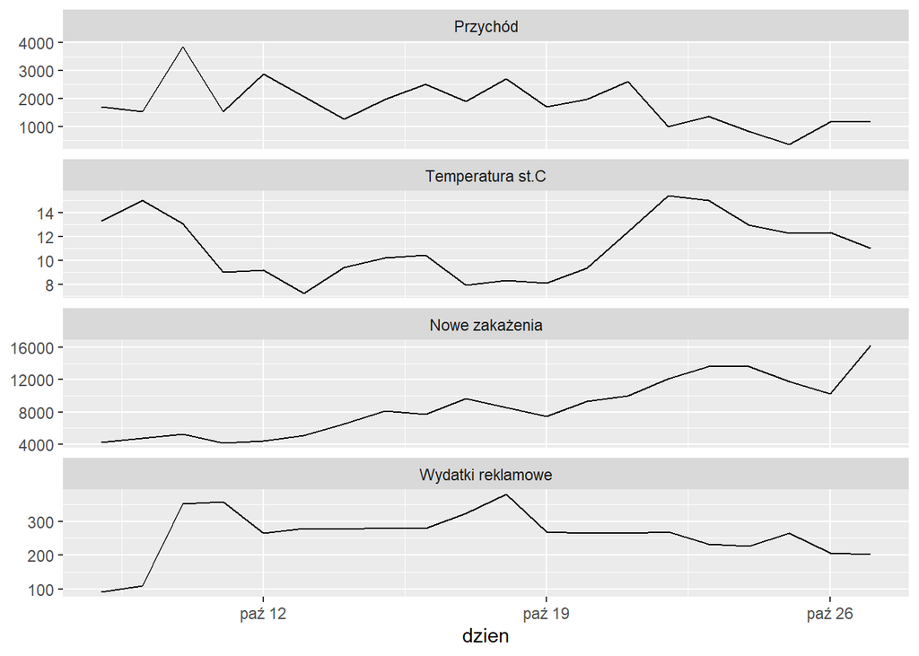

*źródła: baza danych Michała Rogalskiego; stacja pomiarowa w Poznaniu http://www.pimr.poznan.pl/*

### Sezonowość

W poprzednim rozdziale zauważyliśmy, że mimo utrzymania wydatków reklamowych i wzrostu liczby zakażeń, przychody ze sprzedaży zaczęły gwałtownie spadać w drugiej połowie października. Fakt, że tak silnie skorelowana zmienna jak wydatki reklamowe przestały stymulować popyt, oznacza, że musimy poszukać innego czynnika, który wyjaśniałby zachowanie przychodów. W związku ze spadkiem temparatur i liczbie słonecznych dni, racjonalną hipotezą jest twierdzenie o sezonowości w sprzedaży czapek. Aby zweryfikować tę hipotezę posłużymy się testem Chowa. Idea testu polega na arbitralnym wyborze punktu zwrotnego w czasie i sprawdzenie, czy parametry modelów przed i po tym punkcie istotnie różnią się od siebie.**Hipotezę zerową dla naszego przypadku możemy sformułować następująco: model opisujący relację między wydatkami a przychodami jest taki sam dla okresu do 21 października (on-season) jak dla okresu od 22 października (off-season)**

Test Chowa:

```
##      F value        d.f.1        d.f.2      P value
## 2.075897e+01 2.000000e+00 6.700000e+01 9.642807e-08
```

Wynik testu daje nam podstawy do odrzucenia hipotezy zerowej mówiącej o braku sezonowości. Zatem zasadne jest osobne spojrzenie na relację wydatki - przychód w on-seasonie i off-seasonie. Spróbujmy opisać tę relację w tych dwóch przypadkach:

**Model regresji liniowej: przychód ~ wydatki On-season**

```
##
## Call:
## lm(formula = przychod_on ~ budzet_on, data = onseason)
##
## Residuals:
##      Min       1Q   Median       3Q      Max
## -1149.85  -277.77   -87.31   132.46  1234.78
##
## Coefficients:
##             Estimate Std. Error t value Pr(>|t|)
## (Intercept) -230.583    216.027  -1.067    0.296
## budzet_on      8.116      1.013   8.009  2.3e-08 ***
## ---
## Signif. codes:  0 '***' 0.001 '**' 0.01 '*' 0.05 '.' 0.1 ' ' 1
##
## Residual standard error: 595.9 on 25 degrees of freedom
## Multiple R-squared:  0.7196, Adjusted R-squared:  0.7083
## F-statistic: 64.14 on 1 and 25 DF,  p-value: 2.302e-08
```

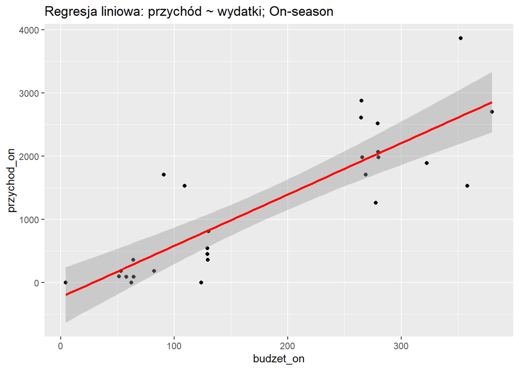

**Interpretacja:** W powyższym modelu regresji liniowej, zmienność wydatków na reklamę wyjaśnia zmiany w przychodach w 72% (wskaźnik determinacji R^2 = 0.7196), co można ocenić na bardzo dobre dopasowanie modelu. Współczynnik regresji *beta = 8.116* mówi, że w on-season’ie wzorst wydatków reklamowych o 100 zł przynosi wzrost dochodów o 811.6 zł

**Model regresji liniowej: przychód ~ wydatki Off-season**

```
##
## Call:
## lm(formula = przychod_off ~ budzet_off, data = offseason)
##
## Residuals:
##     Min      1Q  Median      3Q     Max
## -559.45 -187.32    1.14  183.78  651.10
##
## Coefficients:
##             Estimate Std. Error t value Pr(>|t|)
## (Intercept) 181.5593   106.8390   1.699  0.09665 .
## budzet_off    2.2123     0.7062   3.133  0.00315 **
## ---
## Signif. codes:  0 '***' 0.001 '**' 0.01 '*' 0.05 '.' 0.1 ' ' 1
##
## Residual standard error: 297.9 on 42 degrees of freedom
## Multiple R-squared:  0.1894, Adjusted R-squared:  0.1701
## F-statistic: 9.813 on 1 and 42 DF,  p-value: 0.003154
```

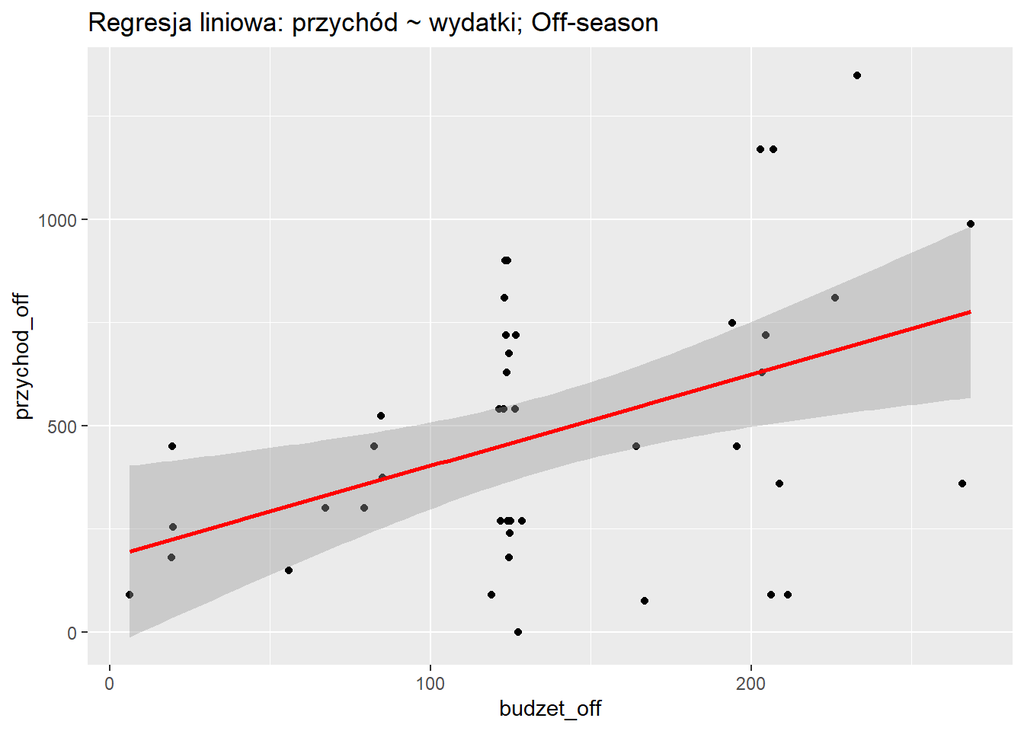

**Interpretacja:** W powyższym modelu regresji liniowej dla **off-seasonu**, zmienność wydatków na reklamę wyjaśnia zmiany w przychodach w 19% (wskaźnik determinacji R^2 = 0.1894), co oceniamy na bardzo niskie dopasowanie, a tym samym uznajemy, że model ten nie jest satysfakcjonującym narzędziem do opisu rzeczywistości. Można zatem twierdzić, że wydatki na reklamę mają bardzo słaby wpływ na przychody w off-season’ie.